# Solutions to Exercises

For each exercise, the solutions below show one possible way of solving it, but you might have used a different approach, and that's great! There is almost always more than one way to solve any particular problem in Python.

## Lesson 1: Intro to Pandas

## Exercise 1.1

a) Initial setup (you can skip to part b if you've already done this):

- Import the `pandas` library
- Use `pandas.read_csv()` to read data from `'https://raw.githubusercontent.com/jenfly/datajam-python/master/data/gapminder.csv'` and store it in a DataFrame called `world`.

```python
import pandas

world = pandas.read_csv('https://raw.githubusercontent.com/jenfly/datajam-python/master/data/gapminder.csv')
```

b) Based on the output of `world.info()`, what data type is the `pop_density` column?

```python
world.info()
```

```
<class 'pandas.core.frame.DataFrame'>
RangeIndex: 2492 entries, 0 to 2491
Data columns (total 13 columns):
 #   Column                 Non-Null Count  Dtype
---  ------                 --------------  -----
 0   country                2492 non-null   object
 1   year                   2492 non-null   int64
 2   population             2492 non-null   int64
 3   region                 2492 non-null   object
 4   sub_region             2492 non-null   object
 5   income_group           2492 non-null   object
 6   life_expectancy        2492 non-null   float64
 7   gdp_per_capita         2492 non-null   int64
 8   children_per_woman     2492 non-null   float64
 9   child_mortality        2492 non-null   float64
 10  pop_density            2492 non-null   float64
 11  years_in_school_men    1780 non-null   float64
 12  years_in_school_women  1780 non-null   float64
dtypes: float64(6), int64(3), object(4)
memory usage: 253.2+ KB
```

The `pop_density` column is of float type.

c) Based on the output of `world.describe()`, what are the minimum and maximum years in this data?

```python
world.describe()
```

|  | year | population | life_expectancy | gdp_per_capita | children_per_woman | child_mortality | pop_density | years_in_school_men | years_in_school_women |
| --- | --- | --- | --- | --- | --- | --- | --- | --- | --- |
| count | 2492.00000 | 2.492000e+03 | 2492.000000 | 2492.000000 | 2492.000000 | 2492.000000 | 2492.000000 | 1780.000000 | 1780.000000 |
| mean | 1982.50000 | 2.667661e+07 | 62.567135 | 10502.302167 | 4.353752 | 105.670024 | 118.014013 | 7.687713 | 6.959556 |
| std | 20.15969 | 1.037838e+08 | 11.518029 | 15478.942158 | 2.049655 | 98.615582 | 372.055683 | 3.242840 | 3.932678 |
| min | 1950.00000 | 2.500000e+04 | 23.800000 | 247.000000 | 1.120000 | 2.200000 | 0.502000 | 0.900000 | 0.210000 |
| 25% | 1965.00000 | 1.730000e+06 | 54.200000 | 1930.000000 | 2.360000 | 24.000000 | 14.275000 | 5.097500 | 3.600000 |
| 50% | 1982.50000 | 5.270000e+06 | 64.650000 | 4925.000000 | 4.340000 | 72.400000 | 44.850000 | 7.635000 | 6.990000 |
| 75% | 2000.00000 | 1.600000e+07 | 71.600000 | 12700.000000 | 6.300000 | 167.000000 | 108.000000 | 10.100000 | 10.000000 |
| max | 2015.00000 | 1.400000e+09 | 83.800000 | 178000.000000 | 8.870000 | 473.000000 | 7910.000000 | 15.300000 | 15.700000 |

The minimum year is 1950 and the maximum year is 2015.

## Exercise 1.2

a) Create a new DataFrame called `americas` which contains the rows of `world` where the region is "Americas" and has the following columns: `country`, `year`, `sub_region`, `income_group`, `pop_density`.

```python
americas = world.loc[world['region'] == 'Americas',
                     ['country', 'year', 'sub_region', 'income_group', 'pop_density']
                    ]
```

b) Use the `head()` and `tail()` methods to display the first 20 and last 20 rows.

```python
americas.head(20)
```

|  | country | year | sub_region | income_group | pop_density |
| --- | --- | --- | --- | --- | --- |
| 56 | Antigua and Barbuda | 1950 | Latin America and the Caribbean | High | 105.00 |
| 57 | Antigua and Barbuda | 1955 | Latin America and the Caribbean | High | 120.00 |
| 58 | Antigua and Barbuda | 1960 | Latin America and the Caribbean | High | 126.00 |
| 59 | Antigua and Barbuda | 1965 | Latin America and the Caribbean | High | 138.00 |
| 60 | Antigua and Barbuda | 1970 | Latin America and the Caribbean | High | 152.00 |
| 61 | Antigua and Barbuda | 1975 | Latin America and the Caribbean | High | 163.00 |
| 62 | Antigua and Barbuda | 1980 | Latin America and the Caribbean | High | 167.00 |
| 63 | Antigua and Barbuda | 1985 | Latin America and the Caribbean | High | 159.00 |
| 64 | Antigua and Barbuda | 1990 | Latin America and the Caribbean | High | 152.00 |
| 65 | Antigua and Barbuda | 1995 | Latin America and the Caribbean | High | 167.00 |
| 66 | Antigua and Barbuda | 2000 | Latin America and the Caribbean | High | 190.00 |
| 67 | Antigua and Barbuda | 2005 | Latin America and the Caribbean | High | 203.00 |
| 68 | Antigua and Barbuda | 2010 | Latin America and the Caribbean | High | 215.00 |
| 69 | Antigua and Barbuda | 2015 | Latin America and the Caribbean | High | 227.00 |
| 70 | Argentina | 1950 | Latin America and the Caribbean | High | 6.27 |
| 71 | Argentina | 1955 | Latin America and the Caribbean | High | 6.92 |
| 72 | Argentina | 1960 | Latin America and the Caribbean | High | 7.53 |
| 73 | Argentina | 1965 | Latin America and the Caribbean | High | 8.14 |
| 74 | Argentina | 1970 | Latin America and the Caribbean | High | 8.76 |
| 75 | Argentina | 1975 | Latin America and the Caribbean | High | 9.53 |

```python
americas.tail(20)
```

|  | country | year | sub_region | income_group | pop_density |
| --- | --- | --- | --- | --- | --- |
| 2388 | Uruguay | 1990 | Latin America and the Caribbean | High | 17.80 |
| 2389 | Uruguay | 1995 | Latin America and the Caribbean | High | 18.40 |
| 2390 | Uruguay | 2000 | Latin America and the Caribbean | High | 19.00 |
| 2391 | Uruguay | 2005 | Latin America and the Caribbean | High | 19.00 |
| 2392 | Uruguay | 2010 | Latin America and the Caribbean | High | 19.30 |
| 2393 | Uruguay | 2015 | Latin America and the Caribbean | High | 19.60 |
| 2422 | Venezuela | 1950 | Latin America and the Caribbean | Upper middle | 6.22 |
| 2423 | Venezuela | 1955 | Latin America and the Caribbean | Upper middle | 7.66 |
| 2424 | Venezuela | 1960 | Latin America and the Caribbean | Upper middle | 9.24 |
| 2425 | Venezuela | 1965 | Latin America and the Caribbean | Upper middle | 11.10 |
| 2426 | Venezuela | 1970 | Latin America and the Caribbean | Upper middle | 13.10 |
| 2427 | Venezuela | 1975 | Latin America and the Caribbean | Upper middle | 15.10 |
| 2428 | Venezuela | 1980 | Latin America and the Caribbean | Upper middle | 17.40 |
| 2429 | Venezuela | 1985 | Latin America and the Caribbean | Upper middle | 19.80 |
| 2430 | Venezuela | 1990 | Latin America and the Caribbean | Upper middle | 22.50 |
| 2431 | Venezuela | 1995 | Latin America and the Caribbean | Upper middle | 25.20 |
| 2432 | Venezuela | 2000 | Latin America and the Caribbean | Upper middle | 27.80 |
| 2433 | Venezuela | 2005 | Latin America and the Caribbean | Upper middle | 30.40 |
| 2434 | Venezuela | 2010 | Latin America and the Caribbean | Upper middle | 32.90 |
| 2435 | Venezuela | 2015 | Latin America and the Caribbean | Upper middle | 35.30 |

c) Use the `unique()` method on the `country` column to display the list of unique countries in the `americas` DataFrame.

```python
americas['country'].unique()
```

```
array(['Antigua and Barbuda', 'Argentina', 'Bahamas', 'Barbados',
       'Belize', 'Bolivia', 'Brazil', 'Canada', 'Chile', 'Colombia',
       'Costa Rica', 'Cuba', 'Dominican Republic', 'Ecuador',
       'El Salvador', 'Grenada', 'Guatemala', 'Guyana', 'Haiti',
       'Honduras', 'Jamaica', 'Mexico', 'Nicaragua', 'Panama', 'Paraguay',
       'Peru', 'Suriname', 'Trinidad and Tobago', 'United States',
       'Uruguay', 'Venezuela'], dtype=object)
```

## Exercise 1.3

For this exercise we're working with the original DataFrame `world` (containing all years and all countries).

a) Initial setup (you can skip to part b if you've already done this):

- Compute the population in millions: divide `world['population']` by `1e6` and assign the result to `world['pop_millions']`.

```python
world['pop_millions'] = world['population'] / 1e6
```

b) Group the DataFrame `world` by year and compute the world total population (in millions) in each year.

```python
world.groupby('year', as_index=False)['pop_millions'].sum()
```

|  | year | pop_millions |
| --- | --- | --- |
| 0 | 1950 | 2521.5914 |
| 1 | 1955 | 2755.4391 |
| 2 | 1960 | 3014.5238 |
| 3 | 1965 | 3317.6620 |
| 4 | 1970 | 3676.8109 |
| 5 | 1975 | 4052.1130 |
| 6 | 1980 | 4428.6840 |
| 7 | 1985 | 4841.1945 |
| 8 | 1990 | 5294.2122 |
| 9 | 1995 | 5714.3521 |
| 10 | 2000 | 6101.9393 |
| 11 | 2005 | 6495.9793 |
| 12 | 2010 | 6918.4071 |
| 13 | 2015 | 7345.2106 |

## Lesson 2: Intro to Data Visualization

## Exercise 2.1

a) Initial setup (you can skip to part b if you've already done this):

- Import the `seaborn` library and give it the nickname `sns`
- Call `sns.set_theme()` (turns on `seaborn` styling)
- Create a DataFrame called `world_2015` which contains only the rows of `world` where the column `year` is equal to 2015.

```python
import seaborn as sns

sns.set_theme()

world_2015 = world[world['year'] == 2015]
```

b) Use `relplot()` to create a scatter plot of `life_expectancy` vs. `gdp_per_capita` from `world_2015`, in which the points are coloured by `income_group`.

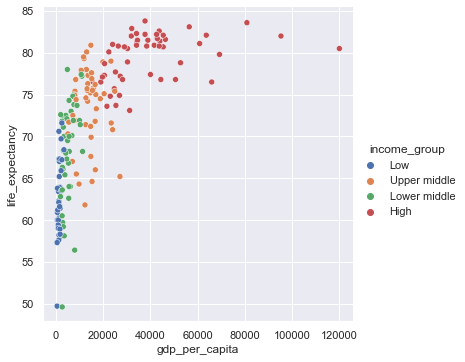

```python
sns.relplot(data=world_2015, x='gdp_per_capita', y='life_expectancy', hue='income_group');
```

c) Add the keyword argument `aspect=1.5` to the `relplot()` function call. How does the plot change?

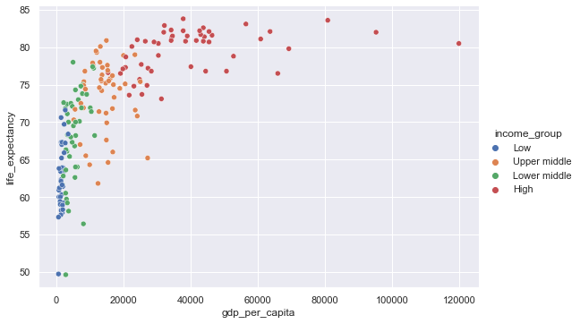

```python
sns.relplot(data=world_2015, x='gdp_per_capita', y='life_expectancy', hue='income_group',
            aspect=1.5);
```

The aspect ratio changes (the plot becomes wider).

## Exercise 2.2

a) Initial setup (you can skip to part b if you've already done this):

- Create a list called `income_order` which contains the following strings: 'Low', 'Lower middle', 'Upper middle', 'High'

```python
income_order= ['Low', 'Lower middle', 'Upper middle', 'High']
```

b) Use `relplot()` to create a plot similar to the previous example, but plotting `life_expectancy` on the y-axis instead of `pop_millions` and aggregating with the mean instead of the sum.

- We want to aggregate with the mean instead of the sum, so you'll need to use the keyword argument `estimator='mean'`.
- Other aspects of the plot are the same as the previous example: use the `world` DataFrame, `year` on the x-axis, `income_group` maps to line colour and style, `income_order` for the `hue_order` argument, and facetting on `region`.

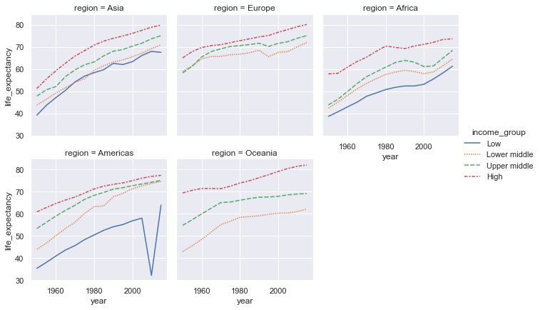

```python
sns.relplot(data=world, x='year', y='life_expectancy', hue='income_group',
            hue_order=income_order, style='income_group', kind='line',
            estimator='mean', ci=None, col='region',
            col_wrap=3, height=3);
```

Bonus: Do you spot anything strange in the subplot for the "Americas" region? How could you investigate this using the techniques we learned in the Intro to Pandas lesson?

There appears to be an outlier in the Americas low income group in 2010. To investigate, we can look at the rows of `world` for this group, to see if anything jumps out:

```python
world[(world['income_group'] == 'Low') & (world['region'] == 'Americas')]
```

|  | country | year | population | region | sub_region | income_group | life_expectancy | gdp_per_capita | children_per_woman | child_mortality | pop_density | years_in_school_men | years_in_school_women | pop_millions |
| --- | --- | --- | --- | --- | --- | --- | --- | --- | --- | --- | --- | --- | --- | --- |
| 938 | Haiti | 1950 | 3220000 | Americas | Latin America and the Caribbean | Low | 35.3 | 2290 | 6.31 | 352.0 | 117.0 | NaN | NaN | 3.22 |
| 939 | Haiti | 1955 | 3510000 | Americas | Latin America and the Caribbean | Low | 38.0 | 2260 | 6.30 | 313.0 | 128.0 | NaN | NaN | 3.51 |
| 940 | Haiti | 1960 | 3870000 | Americas | Latin America and the Caribbean | Low | 40.9 | 2300 | 6.32 | 286.0 | 140.0 | NaN | NaN | 3.87 |
| 941 | Haiti | 1965 | 4270000 | Americas | Latin America and the Caribbean | Low | 43.6 | 2010 | 6.18 | 264.0 | 155.0 | NaN | NaN | 4.27 |
| 942 | Haiti | 1970 | 4710000 | Americas | Latin America and the Caribbean | Low | 45.6 | 1980 | 5.76 | 241.0 | 171.0 | 2.93 | 1.73 | 4.71 |
| 943 | Haiti | 1975 | 5140000 | Americas | Latin America and the Caribbean | Low | 48.3 | 2260 | 5.64 | 215.0 | 187.0 | 3.34 | 2.05 | 5.14 |
| 944 | Haiti | 1980 | 5690000 | Americas | Latin America and the Caribbean | Low | 50.4 | 2860 | 6.06 | 190.0 | 206.0 | 3.81 | 2.42 | 5.69 |
| 945 | Haiti | 1985 | 6380000 | Americas | Latin America and the Caribbean | Low | 52.5 | 2480 | 6.03 | 166.0 | 232.0 | 4.34 | 2.87 | 6.38 |
| 946 | Haiti | 1990 | 7100000 | Americas | Latin America and the Caribbean | Low | 54.1 | 2250 | 5.43 | 145.0 | 258.0 | 4.93 | 3.40 | 7.10 |
| 947 | Haiti | 1995 | 7820000 | Americas | Latin America and the Caribbean | Low | 55.1 | 1680 | 4.89 | 124.0 | 284.0 | 5.59 | 4.04 | 7.82 |
| 948 | Haiti | 2000 | 8550000 | Americas | Latin America and the Caribbean | Low | 56.8 | 1740 | 4.30 | 105.0 | 310.0 | 6.21 | 4.69 | 8.55 |
| 949 | Haiti | 2005 | 9260000 | Americas | Latin America and the Caribbean | Low | 58.0 | 1560 | 3.76 | 89.8 | 336.0 | 6.86 | 5.39 | 9.26 |
| 950 | Haiti | 2010 | 10000000 | Americas | Latin America and the Caribbean | Low | 32.1 | 1500 | 3.33 | 208.0 | 363.0 | 7.52 | 6.12 | 10.00 |
| 951 | Haiti | 2015 | 10700000 | Americas | Latin America and the Caribbean | Low | 63.9 | 1650 | 2.97 | 68.9 | 389.0 | 8.20 | 6.90 | 10.70 |

We can see that the Americas low income group only contains one country, Haiti, and during 2010 there was a large drop in life expectancy. Since there was a devastating earthquake in Haiti in 2010, this drop in life expectancy is likely reflecting these disaster conditions. However, the magnitude of the decrease (from 58 down to 32 years) seems potentially unrealistic and could indicate an issue in how life expectancy was calculated in the Gapminder data.

Back to [home](https://jenfly.github.io/datajam-python/0-jupyter.html)